# Introduction to Statistical learning

Author

Dr. Niloufar Abourashchi and Dr. Thomas Honnor

## Workshop Agenda

- Hypothesis Testing
- Introduction to Statistical Learning
- Examples of `t-test` using `penguin` dataset

## Hypothesis Testing

```r
library(tidyverse)
library(palmerpenguins)
data(penguins)
```

- Assume we would like to investigate some information about the body mass of Adelie penguin in the `palmerpenguin` dataset.
- First, select all the data relating to `Adelie` penguin by using `filter`command

```r
adelie <- penguins %>%
filter(species == "Adelie") %>%
drop_na()
adelie
```

```
# A tibble: 146 × 8
   species island    bill_length_mm bill_depth_mm flipper_length_mm body_mass_g
   <fct>   <fct>              <dbl>         <dbl>             <int>       <int>
 1 Adelie  Torgersen           39.1          18.7               181        3750
 2 Adelie  Torgersen           39.5          17.4               186        3800
 3 Adelie  Torgersen           40.3          18                 195        3250
 4 Adelie  Torgersen           36.7          19.3               193        3450
 5 Adelie  Torgersen           39.3          20.6               190        3650
 6 Adelie  Torgersen           38.9          17.8               181        3625
 7 Adelie  Torgersen           39.2          19.6               195        4675
 8 Adelie  Torgersen           41.1          17.6               182        3200
 9 Adelie  Torgersen           38.6          21.2               191        3800
10 Adelie  Torgersen           34.6          21.1               198        4400
# ℹ 136 more rows
# ℹ 2 more variables: sex <fct>, year <int>
```

- Question: **Is there a difference in body mass for male and female Adelie penguins?**

```r
penguins %>%
filter(species == "Adelie") %>%
drop_na() %>%
group_by(sex) %>%
summarise(count=n(), body_mass_g=mean(body_mass_g))
```

```
# A tibble: 2 × 3
  sex    count body_mass_g
  <fct>  <int>       <dbl>
1 female    73       3369.
2 male      73       4043.
```

```r
t.test(body_mass_g~sex, data=adelie)
```

```
    Welch Two Sample t-test

data:  body_mass_g by sex
t = -13.126, df = 135.69, p-value < 2.2e-16
alternative hypothesis: true difference in means between group female and group male is not equal to 0
95 percent confidence interval:
 -776.3012 -573.0139
sample estimates:
mean in group female   mean in group male
            3368.836             4043.493
```

- Let’s calculate the mean female Adelie body weight:

```r
adelie_f <- filter(adelie, sex=="female")
mu <- mean( adelie_f$body_mass_g )
mu
```

```
[1] 3368.836
```

- CLT states that estimated mean comes from distribution with standard deviation $\sigma/\sqrt{(n)}$
- sigma is true population standard deviation
- $n$ is number of values
- This leads to the standard error associated with the measured mean:

```r
n <- nrow(adelie_f)
n
```

```
[1] 73
```

```r
standard_error <- sd(adelie_f$body_mass_g)/sqrt( n )
standard_error
```

```
[1] 31.52856
```

- Our 95% confidence interval on our mean measurement is

```r
mu-2*standard_error
```

```
[1] 3305.779
```

```r
mu+2*standard_error
```

```
[1] 3431.893
```

- $H_0$: We could test hypothesis that the true population mean for female Adelie penguins is $3310$g.
- This leads to the alternative hypothesis, $H_1$ that the true mean is not $3310$g.
- In this case this value falls within the $95\%$ confidence interval for population mean based on our sample mean, so we can’t reject the hypothesis at the $95\%$ confidence level also known as the $0.05$ alpha significance level.
- **Result**: we fail to reject $H_0$ based on our data.
- Example: $H_0$: We could test hypothesis that the true population mean for female Adelie penguins is $3500$g.
- This leads to the alternative hypothesis, $H_1$ that the true mean is not $3500$g.
- In this case this value falls outside the $95\%$ confidence interval for population mean based on our sample mean, so we can reject the hypothesis at the $95\%$ confidence level also known as the $0.05$ alpha significance level.

### Hypothesis: mass of female Adelie penguins changed from 2007 to 2008

```r
table(adelie_f$year)
```

```
2007 2008 2009
  22   25   26
```

```r
adelie_f_2007_08 <- adelie_f %>% filter(year>=2007, year<=2008)
t.test(body_mass_g~year, adelie_f_2007_08)
```

```
    Welch Two Sample t-test

data:  body_mass_g by year
t = 0.049155, df = 44.801, p-value = 0.961
alternative hypothesis: true difference in means between group 2007 and group 2008 is not equal to 0
95 percent confidence interval:
 -150.8325  158.3780
sample estimates:
mean in group 2007 mean in group 2008
          3389.773           3386.000
```

- When we look at a t-test result.
- We pick a chosen significance level: $95\%$ confidence interval means $0.05$ significance level, and
- $99\%$ confidence interval means $0.01$ significance level.
- We then look at the p-value.
- If the p-value is greater than the significance level we can’t reject the null hypothesis that there is no difference in the means.
- If the p-value is less than the significance level we can reject the null hypothesis that there is no difference in the means at the quoted significance/ confidence level.

**Your Turn!**

- **Example 1:** Use a t-test to test the hypothesis that males and females have different body mass.
- **Example 2:** Use a t-test to see if there is evidence that the penguin bodymass differs for the chinstrap population sampled in 2007 vs the chinstrap population sampled in 2008
- **Example 1:** Use a t-test to test the hypothesis that males and females have different body mass.

```r
chinstrap <- filter(penguins, species=="Chinstrap")
t.test(body_mass_g ~ sex, data = chinstrap)
```

```
    Welch Two Sample t-test

data:  body_mass_g by sex
t = -5.2077, df = 62.575, p-value = 2.264e-06
alternative hypothesis: true difference in means between group female and group male is not equal to 0
95 percent confidence interval:
 -569.7903 -253.7391
sample estimates:
mean in group female   mean in group male
            3527.206             3938.971
```

```r
t.test(body_mass_g ~ sex, data = chinstrap, alternative="less" )
```

```
    Welch Two Sample t-test

data:  body_mass_g by sex
t = -5.2077, df = 62.575, p-value = 1.132e-06
alternative hypothesis: true difference in means between group female and group male is less than 0
95 percent confidence interval:
      -Inf -279.7552
sample estimates:
mean in group female   mean in group male
            3527.206             3938.971
```

- In this case we only get an upper limit on the difference in means i.e. we can place a limit that the mean female body mass is lighter than the mean male body mass by at least $280$g at the $95\%$ confidence level.
- Note we use alternative=“less” because the order of the groups as shown in the output is to compare female (i.e. group 1) against male (i.e. group 2) and we are testing the alternative hypothesis that female is less than female).
- If the groups were the other way round we would use alternative=“greater” (i.e. alternative hypothesis is that male is greater than female).
- Note we can also call the t-test function by passing two vectors of values e.g. in this case we could extract the vector of male and female weights then apply the t-test using code like this: `t.test(body_mass_g_female, body_mass_g_male )`
- **Example 2:**
- In this example we will look to see if there is evidence that the penguin bodymass differed for the chinstrap population sampled in $2007$ vs the chinstrap population sampled in $2008$:

```r
penguins_subset <- penguins %>%
filter(species=="Chinstrap",
sex=="female",
year %in% c(2007,2008)
)
t.test(body_mass_g ~ year, data = penguins_subset)
```

```
    Welch Two Sample t-test

data:  body_mass_g by year
t = 0.63872, df = 15.535, p-value = 0.5323
alternative hypothesis: true difference in means between group 2007 and group 2008 is not equal to 0
95 percent confidence interval:
 -225.7457  419.7628
sample estimates:
mean in group 2007 mean in group 2008
          3569.231           3472.222
```

- In this case although we find a difference mean body mass in $2007$ was $3569$g, and in $2008$ is was lower at $3472$g the difference is not statistically significant (given the sample size) at the $95\%$ level (as the p-value is greater than $0.05$)

#### **Anova test**

- The t-test can be generalised to be applied to more than two data groups using the ANOVA test [analysis of variance](http://www.sthda.com/english/wiki/one-way-anova-test-in-r)
- In R we use the `aov()` function to carry this out:

```r
result_aov <- aov(body_mass_g ~ species, data=penguins)
summary(result_aov)
```

```
             Df    Sum Sq  Mean Sq F value Pr(>F)
species       2 146864214 73432107   343.6 <2e-16 ***
Residuals   339  72443483   213698
---
Signif. codes:  0 '***' 0.001 '**' 0.01 '*' 0.05 '.' 0.1 ' ' 1
2 observations deleted due to missingness
```

- The p-value here is the probability of observing the difference under the null hypothesis that there is no difference in mean body mass between all the species groups.
- This is against the alternative hypothesis that at least one group has a statistically significant difference in mean body mass.
- To actually see the differences between the groups we can use the function TukeyHSD() that reports the differences between the groups in the data:

```r
TukeyHSD(result_aov)
```

```
  Tukey multiple comparisons of means
    95% family-wise confidence level

Fit: aov(formula = body_mass_g ~ species, data = penguins)

$species
                       diff       lwr       upr     p adj
Chinstrap-Adelie   32.42598 -126.5002  191.3522 0.8806666
Gentoo-Adelie    1375.35401 1243.1786 1507.5294 0.0000000
Gentoo-Chinstrap 1342.92802 1178.4810 1507.3750 0.0000000
```

- In this case we can see that there is not a statistically significant difference between the mean Chinstrap and Adelie body masses based on our data sample, but that the differences between the Gentoo / Adelie, and Gentoo / Chinstrap species are statistically significant.
- In this case we can see that there is not a statistically significant difference between the mean Chinstrap and Adelie body masses based on our data sample, but that the differences between the Gentoo / Adelie, and Gentoo / Chinstrap species are statistically significant.

### Useful links

- The following links can be used for further information and examples:

• [Statmethods](https://www.statmethods.net/stats/ttest.html) • [STHDA](http://www.sthda.com/english/wiki/unpaired-two-samples-t-test-in-r) • [t-test](https://uc-r.github.io/t_test) • [The Pirate’s guide to R](https://bookdown.org/ndphillips/YaRrr/t-test-t-test.html)

## Concepts in Statistical learning

## 1. Supervised vs Unsupervised Learning

- **Supervised Learning** involves training a model on a labeled dataset, which means that each training example is paired with an output label. The goal is to learn a mapping from inputs to outputs that can be used to predict the labels of new, unseen data. Common supervised learning tasks include classification and regression.
- **Unsupervised Learning** involves training a model on data that does not have labeled responses. The goal is to infer the natural structure present within a set of data points. Common unsupervised learning tasks include clustering and dimensionality reduction.

### Useful resources

- [ISLR pdf version](https://www.statlearning.com/s/ISLRSeventhPrinting.pdf)
- [ISLR online](https://www.statlearning.com/)

[figure not shown]

## 2. Classification vs Regression

- **Classification** is a type of supervised learning where the output variable is categorical. The goal is to predict the class or category to which a new data point belongs. Examples include spam detection (spam or not spam) and image recognition (identifying objects in images).
- **Regression** is another type of supervised learning where the output variable is continuous. The goal is to predict a numerical value given some input data. Examples include predicting house prices and forecasting stock prices.

## 3. Definition for Linear Models

Linear models are a foundational concept in statistical learning where the relationship between the input variables (features) and the output variable (response) is assumed to be linear. The input variables are usually denoted by $X$, and the output variable is denoted by $Y$.

- **Input (X):** A set of predictor variables or features.
- **Output (Y):** The response or target variable that we aim to predict.

## 4. Linear Model Formula

The formula for a simple linear model is given by:

$$Y = \beta_0 + \beta_1 X_1 + \beta_2 X_2 + \ldots + \beta_p X_p + \epsilon$$

where:

- $Y$ is the dependent variable (output).
- $\beta_0$ is the intercept. $\beta_1, \beta_2, \ldots, \beta_p$ are the coefficients of the predictor variables $(X_1, X_2, \ldots, X_p).$
- $\epsilon$ is the error term representing the variability in $(Y)$ that cannot be explained by the predictors.

## 5. Visual Representation of $\epsilon$

In a graph of the linear model, the term $\epsilon$ represents the deviation of the observed values from the predicted values. It accounts for the noise or randomness in the data.

$$Y = f(X) + \epsilon$$

where $f(X)$ is the true function that relates $X$ to $Y$, and $\epsilon$ is the error term. Below is a graphical illustration:

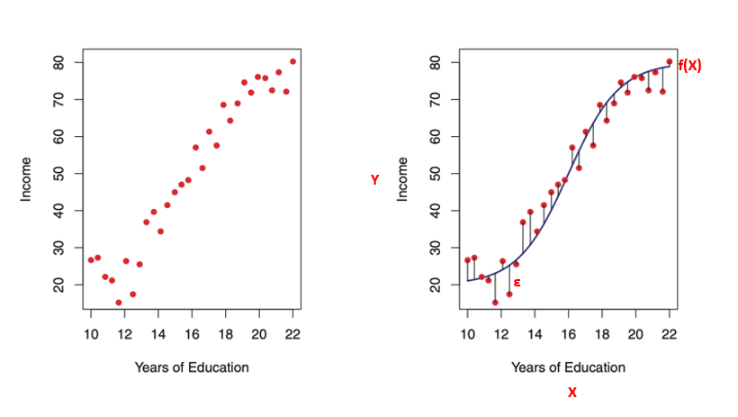

## 6. Definitions of $\hat {Y}$ and $\hat{f}(X)$

- $\hat{Y}$ is the predicted value of the output $Y$.
- $\hat{f}(X)$ is the estimated function based on the training data, used to predict $\hat{Y}$.

The predicted value $\hat{Y}$ is given by the fitted linear model:

$$\hat{Y} = \hat{f}(X) = \hat{\beta}_0 + \hat{\beta}_1 X_1 + \hat{\beta}_2 X_2 + \ldots + \hat{\beta}_p X_p$$

where $\hat{\beta}_0, \hat{\beta}_1, \hat{\beta}_2, \ldots, \hat{\beta}_p$ are the estimated coefficients obtained from the training data.

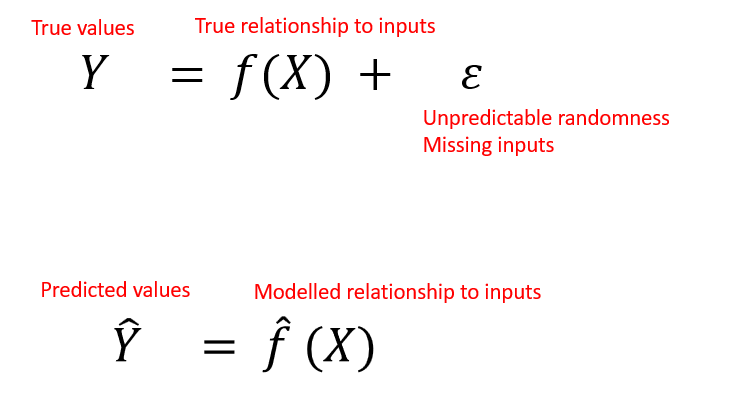

### Some More graph for Predicting`income`by`years of education`

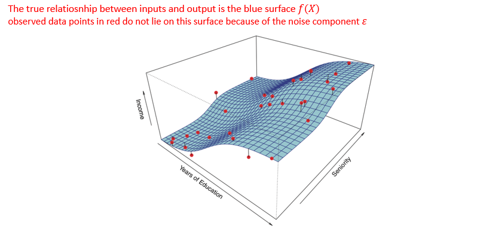

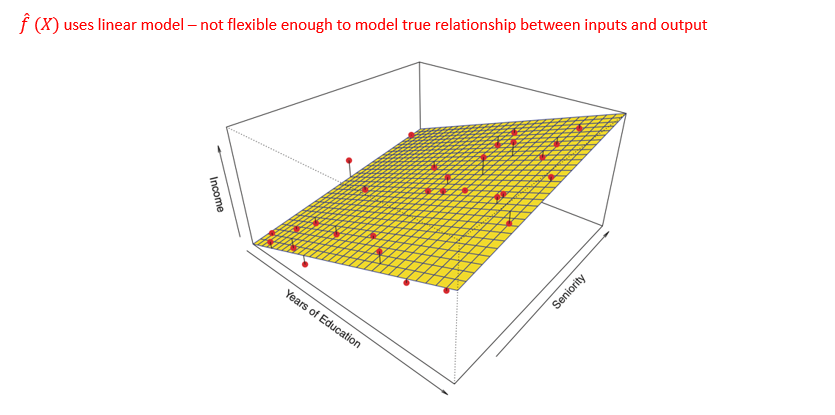

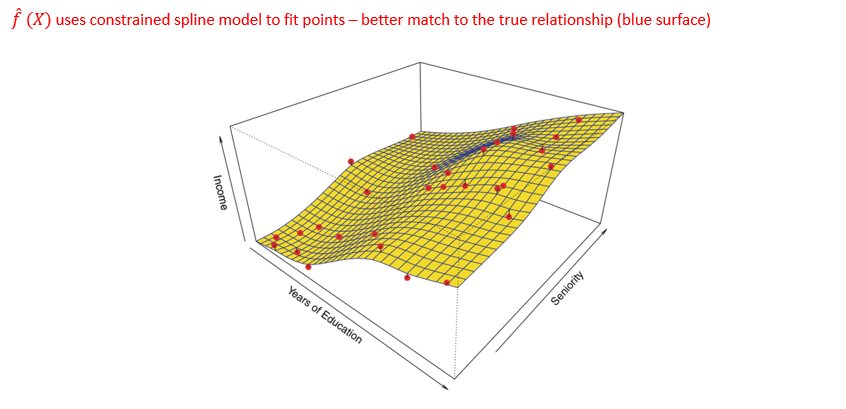

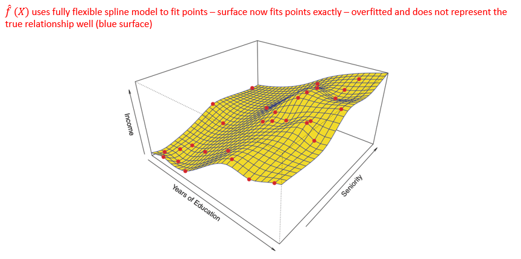

#### Assumptions of linear regression and interpreting R squared value

- Some notes on interpreting R squared values and on the LINE assumptions that must apply in order for the results and predictions of linear regression to hold.
- Interpreting $R^2$
1. $R^2=0$ *does not always imply input and output are uncorrelated*
2. In the plot below , although a linear fit is not a good model, one can see a non-linear model can be a very good fit.

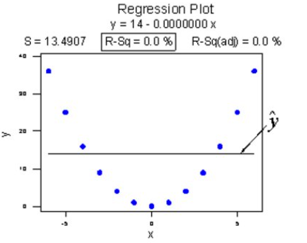

c. $R^2$ high does not mean linear fit is best.

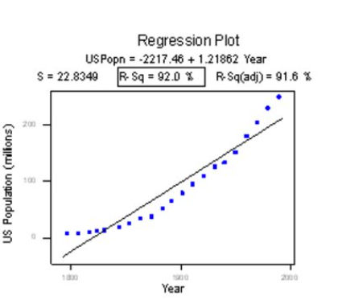

- Here a curved fit would give a higher $R^2$
4. Outliers can have a big effect of the fit

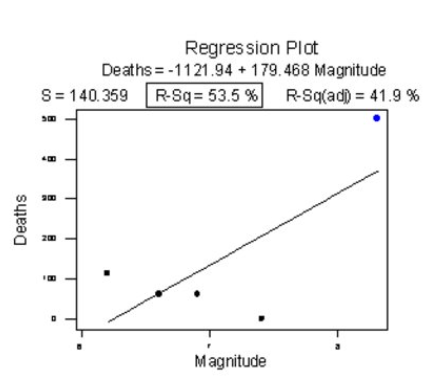

- Test and refit removing outliers.
- If variables do have linear relationship then it should not change fit by large amount.

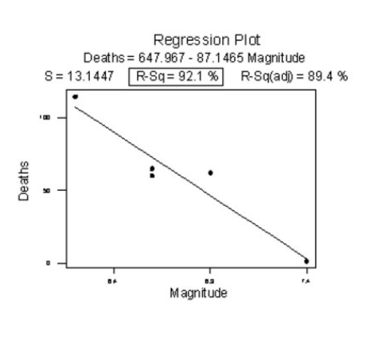